# automatization_notebook_04

Meder Imanaliev

2024-10-27

# Чтение данных

В вашем варианте нужно использовать датасет healthcare-dataset-stroke-data.

```r
library(tidyverse)
stroke_data <- read_csv("healthcare-dataset-stroke-data.csv")
```

# Выведите общее описание данных

```r
stroke_data %>%
  glimpse()
```

```
## Rows: 5,110
## Columns: 12
## $ id                <dbl> 9046, 51676, 31112, 60182, 1665, 56669, 53882, 10434…
## $ gender            <chr> "Male", "Female", "Male", "Female", "Female", "Male"…
## $ age               <dbl> 67, 61, 80, 49, 79, 81, 74, 69, 59, 78, 81, 61, 54, …
## $ hypertension      <dbl> 0, 0, 0, 0, 1, 0, 1, 0, 0, 0, 1, 0, 0, 0, 0, 1, 0, 1…
## $ heart_disease     <dbl> 1, 0, 1, 0, 0, 0, 1, 0, 0, 0, 0, 1, 0, 1, 1, 0, 1, 0…
## $ ever_married      <chr> "Yes", "Yes", "Yes", "Yes", "Yes", "Yes", "Yes", "No…
## $ work_type         <chr> "Private", "Self-employed", "Private", "Private", "S…
## $ Residence_type    <chr> "Urban", "Rural", "Rural", "Urban", "Rural", "Urban"…
## $ avg_glucose_level <dbl> 228.69, 202.21, 105.92, 171.23, 174.12, 186.21, 70.0…
## $ bmi               <chr> "36.6", "N/A", "32.5", "34.4", "24", "29", "27.4", "…
## $ smoking_status    <chr> "formerly smoked", "never smoked", "never smoked", "…
## $ stroke            <dbl> 1, 1, 1, 1, 1, 1, 1, 1, 1, 1, 1, 1, 1, 1, 1, 1, 1, 1…
```

# Очистка данных

1. Уберите переменные, в которых пропущенных значений больше 20% или уберите субъектов со слишком большим количеством пропущенных значений. Или совместите оба варианта. Напишите обоснование, почему вы выбрали тот или иной вариант:

**Обоснование**: все переменные прошли порог. Так как большинство пропусков содержится только в переменной bmi (и то, меньше установленного порога), то принял решение ничего не удалять.

2. Переименуйте переменные в человекочитаемый вид (что делать с пробелами в названиях?);
3. В соответствии с описанием данных приведите переменные к нужному типу (numeric или factor);
4. Отсортируйте данные по возрасту по убыванию;
5. Сохраните в файл outliers.csv субъектов, которые являются выбросами (например, по правилу трёх сигм) — это необязательное задание со звёздочкой;
6. Присвойте получившийся датасет переменной “cleaned_data”.

```r
# 1
threshold_variable <- 0.2
subject_threshold <- 0.2

clean_data <- stroke_data %>%
  select(where(~ mean(is.na(.), na.rm = TRUE) <= threshold_variable)) %>%
  filter(rowMeans(is.na(.), na.rm = TRUE) <= subject_threshold)

# 2
cleaned_data <- clean_data %>%
  rename(
    Unique_ID = id,
    Age = age,
    Gender = gender,
    Hypertension = hypertension,
    Heart_Disease = heart_disease,
    Ever_Married = ever_married,
    Work_Type = work_type,
    Residence_Type = Residence_type,
    Avg_Glucose_Level = avg_glucose_level,
    BMI = bmi,
    Smoking_Status = smoking_status,
    Stroke_Status = stroke
  )

# 3
cleaned_data <- cleaned_data %>%
  mutate(
    across(c(Unique_ID, Age, Avg_Glucose_Level), as.numeric),
    BMI = as.numeric(replace(BMI, BMI == "N/A", NA)),
    Ever_Married = as.logical(Ever_Married == "Yes"),
    across(c(Gender, Hypertension, Heart_Disease, Work_Type, Residence_Type, Smoking_Status, Stroke_Status), as.factor)
  )

str(cleaned_data)
```

```
## tibble [5,110 × 12] (S3: tbl_df/tbl/data.frame)
##  $ Unique_ID        : num [1:5110] 9046 51676 31112 60182 1665 ...
##  $ Gender           : Factor w/ 3 levels "Female","Male",..: 2 1 2 1 1 2 2 1 1 1 ...
##  $ Age              : num [1:5110] 67 61 80 49 79 81 74 69 59 78 ...
##  $ Hypertension     : Factor w/ 2 levels "0","1": 1 1 1 1 2 1 2 1 1 1 ...
##  $ Heart_Disease    : Factor w/ 2 levels "0","1": 2 1 2 1 1 1 2 1 1 1 ...
##  $ Ever_Married     : logi [1:5110] TRUE TRUE TRUE TRUE TRUE TRUE ...
##  $ Work_Type        : Factor w/ 5 levels "children","Govt_job",..: 4 5 4 4 5 4 4 4 4 4 ...
##  $ Residence_Type   : Factor w/ 2 levels "Rural","Urban": 2 1 1 2 1 2 1 2 1 2 ...
##  $ Avg_Glucose_Level: num [1:5110] 229 202 106 171 174 ...
##  $ BMI              : num [1:5110] 36.6 NA 32.5 34.4 24 29 27.4 22.8 NA 24.2 ...
##  $ Smoking_Status   : Factor w/ 4 levels "formerly smoked",..: 1 2 2 3 2 1 2 2 4 4 ...
##  $ Stroke_Status    : Factor w/ 2 levels "0","1": 2 2 2 2 2 2 2 2 2 2 ...
```

```r
# 4
cleaned_data <- cleaned_data %>%
  arrange(desc(Age))

head(cleaned_data)
```

```
## # A tibble: 6 × 12
##   Unique_ID Gender   Age Hypertension Heart_Disease Ever_Married Work_Type
##       <dbl> <fct>  <dbl> <fct>        <fct>         <lgl>        <fct>
## 1     64778 Male      82 0            1             TRUE         Private
## 2     39373 Female    82 1            0             TRUE         Self-employed
## 3       712 Female    82 1            1             FALSE        Private
## 4     61960 Male      82 0            1             TRUE         Private
## 5     38829 Female    82 0            0             TRUE         Private
## 6     37132 Male      82 0            0             TRUE         Govt_job
## # ℹ 5 more variables: Residence_Type <fct>, Avg_Glucose_Level <dbl>, BMI <dbl>,
## #   Smoking_Status <fct>, Stroke_Status <fct>
```

```r
#5
outliers <- cleaned_data %>%
  filter(
    (Age < mean(Age, na.rm = TRUE) - 3 * sd(Age, na.rm = TRUE) |
     Age > mean(Age, na.rm = TRUE) + 3 * sd(Age, na.rm = TRUE)) |

    (Avg_Glucose_Level < mean(Avg_Glucose_Level, na.rm = TRUE) - 3 * sd(Avg_Glucose_Level, na.rm = TRUE) |
     Avg_Glucose_Level > mean(Avg_Glucose_Level, na.rm = TRUE) + 3 * sd(Avg_Glucose_Level, na.rm = TRUE)) |

    (BMI < mean(BMI, na.rm = TRUE) - 3 * sd(BMI, na.rm = TRUE) |
     BMI > mean(BMI, na.rm = TRUE) + 3 * sd(BMI, na.rm = TRUE))
  )

write.csv(outliers, "outliers.csv", row.names = FALSE)

# 6

cleaned_data <- anti_join(cleaned_data, outliers, by = "Unique_ID")
```

# Сколько осталось переменных?

```r
num_var <- ncol(cleaned_data)
num_var
```

```
## [1] 12
```

# Сколько осталось случаев?

```r
num_cases <- nrow(cleaned_data)
num_cases
```

```
## [1] 5003
```

# Есть ли в данных идентичные строки?

```r
num_duplicates <- sum(duplicated(cleaned_data))
num_duplicates
```

```
## [1] 0
```

# Сколько всего переменных с пропущенными значениями в данных и сколько пропущенных точек в каждой такой переменной?

```r
num_missing <- sum(colSums(is.na(cleaned_data)) > 0)

na_counts <- colSums(is.na(cleaned_data))
na_counts <- na_counts[na_counts > 0]

cat("Всего пропущено:", num_missing, "\n")
```

```
## Всего пропущено: 1
```

```r
print(na_counts)
```

```
## BMI
## 198
```

# Описательные статистики

## Количественные переменные

1. Рассчитайте для всех количественных переменных для каждой группы (stroke):

1.1) Количество значений;

1.2) Количество пропущенных значений;

1.3) Среднее;

1.4) Медиану;

1.5) Стандартное отклонение;

1.6) 25% квантиль и 75% квантиль;

1.7) Интерквартильный размах;

1.8) Минимум;

1.9) Максимум;

1.10) 95% ДИ для среднего - задание со звёздочкой.

```r
stats <- function(x) {
  n <- length(x)
  na_count <- sum(is.na(x))
  mean_val <- mean(x, na.rm = TRUE)
  median_val <- median(x, na.rm = TRUE)
  sd_val <- sd(x, na.rm = TRUE)
  q25 <- quantile(x, 0.25, na.rm = TRUE)
  q75 <- quantile(x, 0.75, na.rm = TRUE)
  iqr_val <- IQR(x, na.rm = TRUE)
  min_val <- min(x, na.rm = TRUE)
  max_val <- max(x, na.rm = TRUE)

  se <- sd_val / sqrt(n - na_count)
  ci_lower <- mean_val - 1.96 * se
  ci_upper <- mean_val + 1.96 * se
  ci <- paste0(round(ci_lower, 2), " - ", round(ci_upper, 2))

  return(c(
    'Количество значений' = n,
    'Количество пропущенных значений' = na_count,
    'Среднее' = round(mean_val, 2),
    'Медиана' = round(median_val, 2),
    'Стандартное отклонение' = round(sd_val, 2),
    '25% квантиль' = round(q25, 2),
    '75% квантиль' = round(q75, 2),
    'Интерквартильный размах' = round(iqr_val, 2),
    'Минимум' = round(min_val, 2),
    'Максимум' = round(max_val, 2),
    '95% ДИ для среднего' = ci
  ))
}


cleaned_data %>%
  group_by(Stroke_Status) %>%
  summarise(across(
    where(is.numeric) & !matches("Unique_ID"),
    ~ list(stats(.x))
  ), .groups = "drop") %>%
  pivot_longer(-Stroke_Status, names_to = "Переменная", values_to = "Статистика") %>%
  unnest_wider(Статистика) %>%
  flextable() %>%
  set_header_labels(
    Stroke_Status = "Группа (инсульт)",
    Переменная = "Переменная",
    `Количество значений` = "Количество значений",
    `Количество пропущенных значений` = "Пропущенные значения",
    Среднее = "Среднее",
    Медиана = "Медиана",
    `Стандартное отклонение` = "Ст. отклонение",
    `25% квантиль` = "25% квантиль",
    `75% квантиль` = "75% квантиль",
    `Интерквартильный размах` = "Интеркв. размах",
    Минимум = "Минимум",
    Максимум = "Максимум",
    `95% ДИ для среднего` = "95% ДИ для среднего"
  ) %>%
  theme_box() %>%
  autofit() %>%
  align(align = "center", part = "all")
```

| Группа (инсульт) | Переменная | Количество значений | Пропущенные значения | Среднее | Медиана | Ст. отклонение | 25% квантиль.25% | 75% квантиль.75% | Интеркв. размах | Минимум | Максимум | 95% ДИ для среднего |
| --- | --- | --- | --- | --- | --- | --- | --- | --- | --- | --- | --- | --- |
| 0 | Age | 4764 | 0 | 41.75 | 43 | 22.34 | 24 | 59 | 35 | 0.08 | 82 | 41.11 - 42.38 |
| 0 | Avg_Glucose_Level | 4764 | 0 | 103.38 | 91.17 | 41.65 | 77.01 | 112.11 | 35.11 | 55.12 | 240.86 | 102.19 - 104.56 |
| 0 | BMI | 4764 | 158 | 28.44 | 27.8 | 7.18 | 23.4 | 32.8 | 9.4 | 10.3 | 52.3 | 28.23 - 28.65 |
| 1 | Age | 239 | 0 | 67.65 | 71 | 12.79 | 59 | 78 | 19 | 1.32 | 82 | 66.03 - 69.28 |
| 1 | Avg_Glucose_Level | 239 | 0 | 127.61 | 104.12 | 58.13 | 78.81 | 190.96 | 112.16 | 56.11 | 240.59 | 120.24 - 134.98 |
| 1 | BMI | 239 | 40 | 30.13 | 29.3 | 6.02 | 26.35 | 33.1 | 6.75 | 16.9 | 48.9 | 29.3 - 30.97 |

## Категориальные переменные

1. Рассчитайте для всех категориальных переменных для каждой группы (stroke):

1.1) Абсолютное количество;

1.2) Относительное количество внутри группы;

1.3) 95% ДИ для доли внутри группы - задание со звёздочкой.

```r
ci_calc <- function(count, total) {
  prop <- count / total
  se <- sqrt(prop * (1 - prop) / total)
  ci_lower <- max(0, prop - 1.96 * se)
  ci_upper <- min(1, prop + 1.96 * se)
  ci <- paste0(round(ci_lower * 100, 2), "% - ", round(ci_upper * 100, 2), "%")
  return(ci)
}

cleaned_data %>%
  group_by(Stroke_Status) %>%
  select(where(is.factor), -Unique_ID) %>%
  pivot_longer(-Stroke_Status, names_to = "Переменная", values_to = "Значение") %>%
  count(Stroke_Status, Переменная, Значение) %>%
  group_by(Stroke_Status, Переменная) %>%
  mutate(
    `Абсолютное количество` = n,
    `Относительное количество (%)` = round(n / sum(n) * 100, 2),
    `95% ДИ для доли` = ci_calc(n, sum(n))
  ) %>%
  select(-n) %>%
  ungroup() %>%
  arrange(Stroke_Status, Переменная, desc(`Абсолютное количество`)) %>%
  flextable() %>%
  set_header_labels(
    Stroke_Status = "Группа (инсульт)",
    Переменная = "Переменная",
    Значение = "Значение",
    `Абсолютное количество` = "Абс. кол-во",
    `Относительное количество (%)` = "Отн. кол-во (%)",
    `95% ДИ для доли` = "95% ДИ для доли внутри группы"
  ) %>%
  theme_box() %>%
  autofit() %>%
  align(align = "center", part = "all")
```

| Группа (инсульт) | Переменная | Значение | Абс. кол-во | Отн. кол-во (%) | 95% ДИ для доли внутри группы |
| --- | --- | --- | --- | --- | --- |
| 0 | Gender | Female | 2,788 | 58.52 | 57.12% - 0.06% |
| 0 | Gender | Male | 1,975 | 41.46 | 57.12% - 0.06% |
| 0 | Gender | Other | 1 | 0.02 | 57.12% - 0.06% |
| 0 | Heart_Disease | 0 | 4,541 | 95.32 | 94.72% - 5.28% |
| 0 | Heart_Disease | 1 | 223 | 4.68 | 94.72% - 5.28% |
| 0 | Hypertension | 0 | 4,355 | 91.41 | 90.62% - 9.38% |
| 0 | Hypertension | 1 | 409 | 8.59 | 90.62% - 9.38% |
| 0 | Residence_Type | Urban | 2,412 | 50.63 | 49.21% - 50.79% |
| 0 | Residence_Type | Rural | 2,352 | 49.37 | 49.21% - 50.79% |
| 0 | Smoking_Status | never smoked | 1,763 | 37.01 | 35.64% - 16.3% |
| 0 | Smoking_Status | Unknown | 1,478 | 31.02 | 35.64% - 16.3% |
| 0 | Smoking_Status | formerly smoked | 795 | 16.69 | 35.64% - 16.3% |
| 0 | Smoking_Status | smokes | 728 | 15.28 | 35.64% - 16.3% |
| 0 | Work_Type | Private | 2,715 | 56.99 | 55.58% - 0.65% |
| 0 | Work_Type | Self-employed | 733 | 15.39 | 55.58% - 0.65% |
| 0 | Work_Type | children | 685 | 14.38 | 55.58% - 0.65% |
| 0 | Work_Type | Govt_job | 609 | 12.78 | 55.58% - 0.65% |
| 0 | Work_Type | Never_worked | 22 | 0.46 | 55.58% - 0.65% |
| 1 | Gender | Female | 138 | 57.74 | 51.48% - 48.52% |
| 1 | Gender | Male | 101 | 42.26 | 51.48% - 48.52% |
| 1 | Heart_Disease | 0 | 196 | 82.01 | 77.14% - 22.86% |
| 1 | Heart_Disease | 1 | 43 | 17.99 | 77.14% - 22.86% |
| 1 | Hypertension | 0 | 179 | 74.90 | 69.4% - 30.6% |
| 1 | Hypertension | 1 | 60 | 25.10 | 69.4% - 30.6% |
| 1 | Residence_Type | Urban | 131 | 54.81 | 48.5% - 51.5% |
| 1 | Residence_Type | Rural | 108 | 45.19 | 48.5% - 51.5% |
| 1 | Smoking_Status | never smoked | 86 | 35.98 | 29.9% - 21% |
| 1 | Smoking_Status | formerly smoked | 67 | 28.03 | 29.9% - 21% |
| 1 | Smoking_Status | Unknown | 47 | 19.67 | 29.9% - 21% |
| 1 | Smoking_Status | smokes | 39 | 16.32 | 29.9% - 21% |
| 1 | Work_Type | Private | 141 | 59.00 | 52.76% - 1.99% |
| 1 | Work_Type | Self-employed | 64 | 26.78 | 52.76% - 1.99% |
| 1 | Work_Type | Govt_job | 32 | 13.39 | 52.76% - 1.99% |
| 1 | Work_Type | children | 2 | 0.84 | 52.76% - 1.99% |

# Визуализация

## Количественные переменные

1. Для каждой количественной переменной сделайте боксплоты по группам. Расположите их либо на отдельных рисунках, либо на одном, но читаемо;
2. Наложите на боксплоты beeplots - задание со звёздочкой.
3. Раскрасьте боксплоты с помощью библиотеки RColorBrewer.

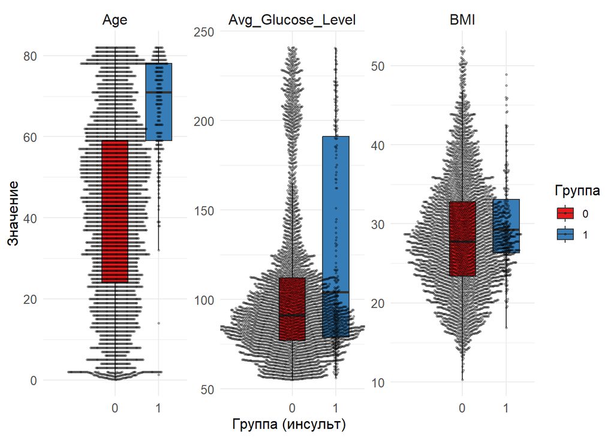

```r
quant_plot <- cleaned_data %>%
  pivot_longer(cols = where(is.numeric) & !matches("Unique_ID"),
               names_to = "Переменная",
               values_to = "Значение") %>%
  filter(!is.na(Значение)) %>%
  ggplot(aes(x = factor(Stroke_Status), y = Значение, fill = factor(Stroke_Status))) +
  geom_boxplot(outlier.shape = NA, width = 0.6) +
  geom_beeswarm(alpha = 0.3, size = 0.5, dodge.width = 0.6) +
  scale_fill_brewer(palette = "Set1") +
  facet_wrap(~ Переменная, scales = "free_y", nrow = 1) +
  labs(x = "Группа (инсульт)", y = "Значение", fill = "Группа") +
  theme_minimal() +
  theme(
    strip.text = element_text(size = 12),
    axis.text = element_text(size = 10),
    axis.title = element_text(size = 12),
    legend.title = element_text(size = 12)
  )

print(quant_plot)
```

## Категориальные переменные

1. Сделайте подходящие визуализации категориальных переменных. Обоснуйте, почему выбрали именно этот тип. Я выбрал столбчатые диаграмммы, посколько категорий немного для каждой переменной и легко визуально оценить распределение каждой из них. Добавил абсолютные значения на каждую диаграмму. Еще была идея сделать пай-чарт, но я подумал, что барплоты интуитивно понятнее.

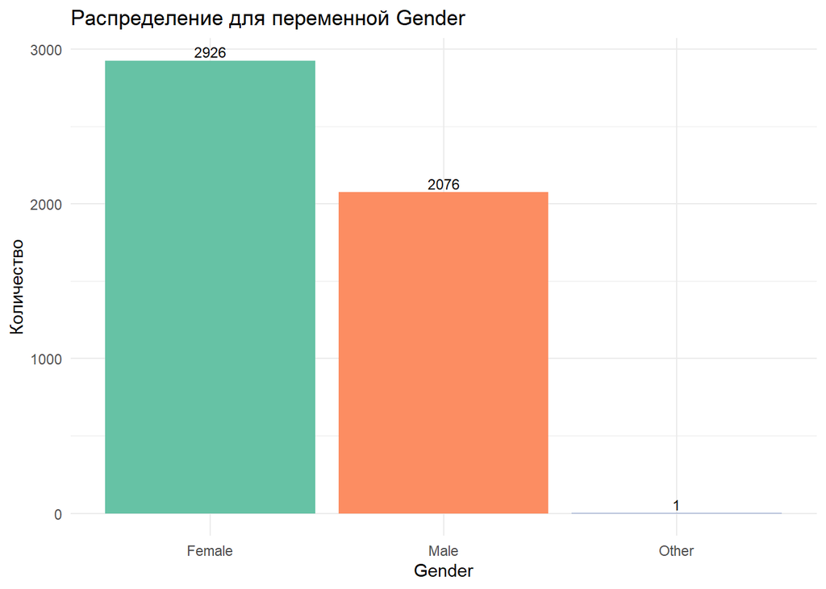

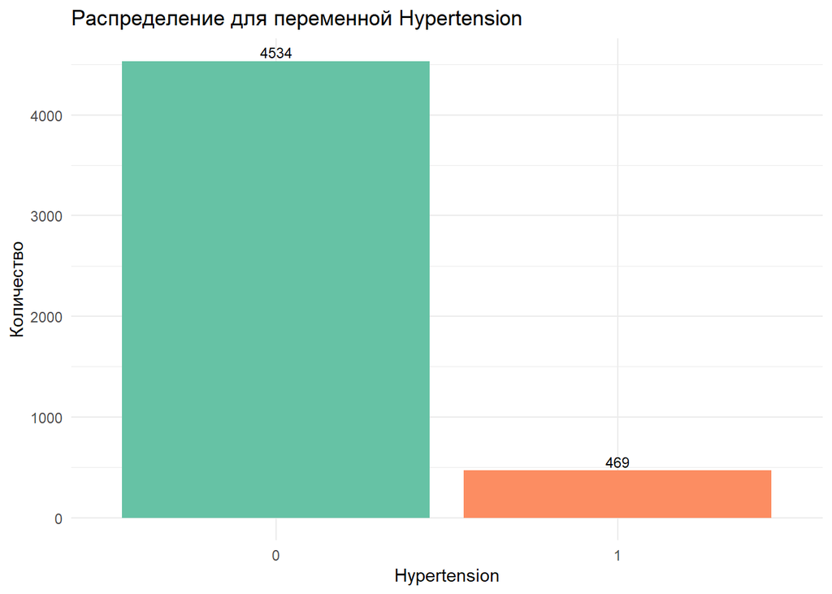

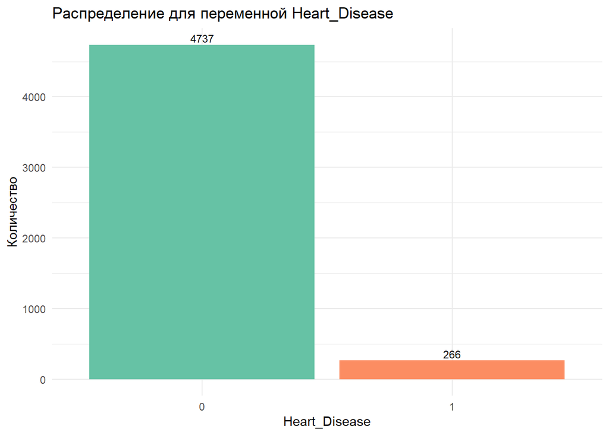

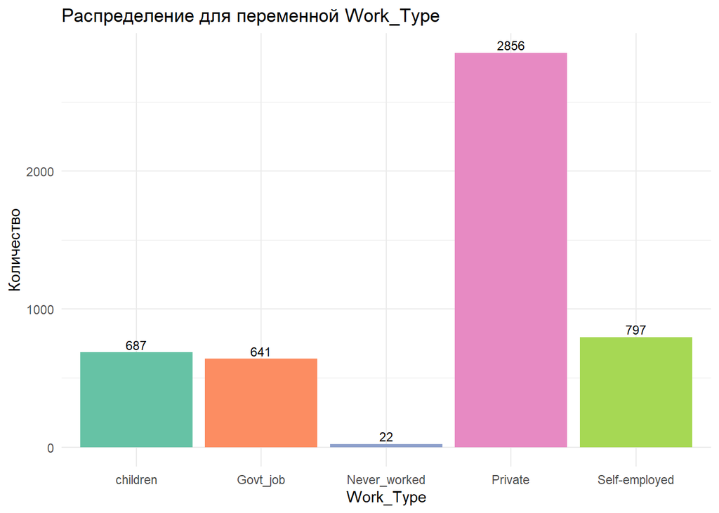

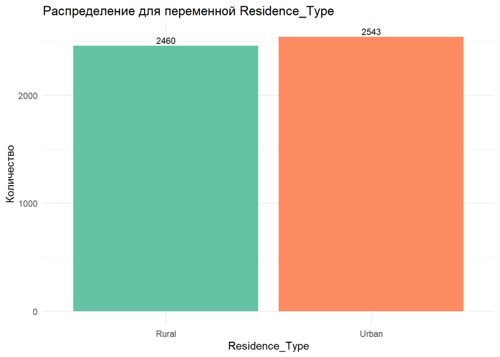

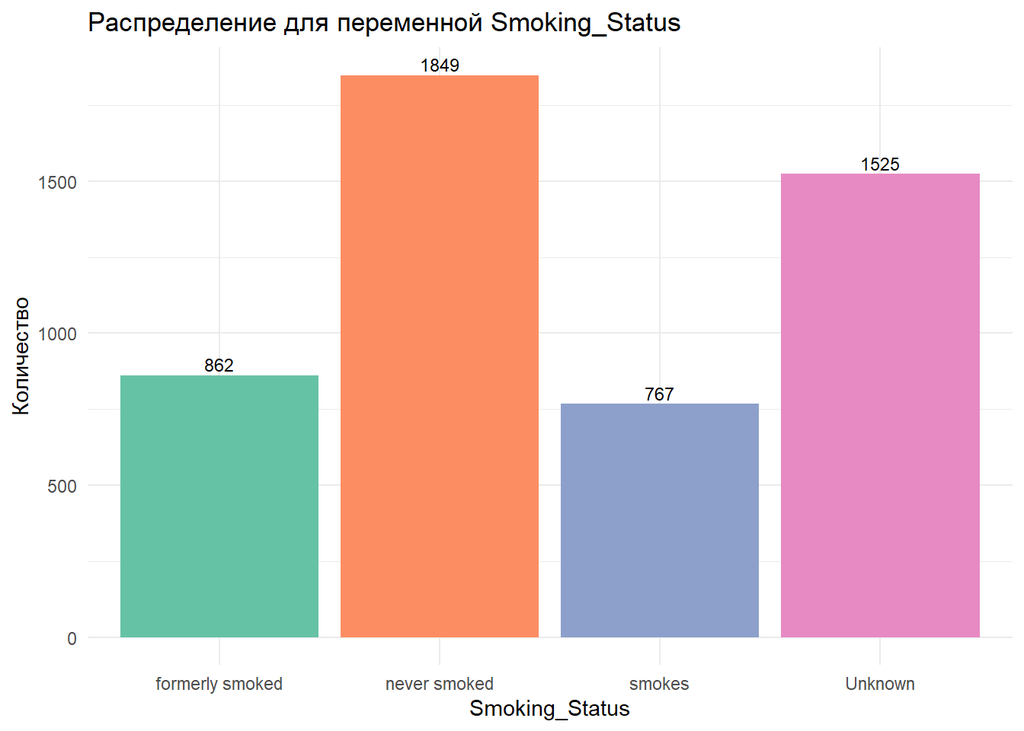

```r
colors <- brewer.pal(n = 6, name = "Set2")

cat_col <- cleaned_data %>%
  select(where(is.factor), -Stroke_Status) %>%
  colnames()

cat_barplot <- function(data, categorical, colors) {
  ggplot(data, aes_string(x = categorical, fill = categorical)) +
    geom_bar() +
    geom_text(stat = "count", aes(label = ..count..),
              vjust = -0.3, size = 3) +
    scale_fill_manual(values = colors) +
    theme_minimal() +
    labs(title = paste("Распределение для переменной", categorical),
         x = categorical, y = "Количество") +
    theme(legend.position = "none")
}

for (cat_var in cat_col) {
  print(cat_barplot(cleaned_data, cat_var, colors))
}
```

# Статистические оценки

## Проверка на нормальность

1. Оцените каждую переменную на соответствие нормальному распределению с помощью теста Шапиро-Уилка. Какие из переменных являются нормальными и как как вы это поняли? Для каждой количественной переменной (Age, Avg_Glucose_Level, BMI) значения p-value значительно меньше 0.05 как для группы Stroke_Status = 0, так и для группы Stroke_Status = 1. Это означает, что для всех переменных и в обеих группах данные не распределены нормально, поскольку нулевая гипотеза о нормальном распределении отвергается (p-value < 0.05).

```r
normality_test <- cleaned_data %>%
  group_by(Stroke_Status) %>%
  summarise(
    p_value_Age = shapiro.test(Age)$p.value,
    p_value_Avg_Glucose_Level = shapiro.test(Avg_Glucose_Level)$p.value,
    p_value_BMI = shapiro.test(BMI)$p.value
  )

normality_test
```

```
## # A tibble: 2 × 4
##   Stroke_Status p_value_Age p_value_Avg_Glucose_Level p_value_BMI
##   <fct>               <dbl>                     <dbl>       <dbl>
## 1 0                2.38e-30                  9.56e-60    3.23e-22
## 2 1                5.83e-13                  6.37e-14    6.66e- 5
```

2. Постройте для каждой количественной переменной QQ-плот. Отличаются ли выводы от теста Шапиро-Уилка? Какой метод вы бы предпочли и почему? Графики согласуются с результатами теста Шапиро-Уилка,т.к.демонстрируют значительные отклонения от прямой линии. Я бы предпочел QQ-плот для визуальной оценки нормальности, особенно в больших данных, так как он позволяет увидеть, где именно распределение отклоняется от нормального.

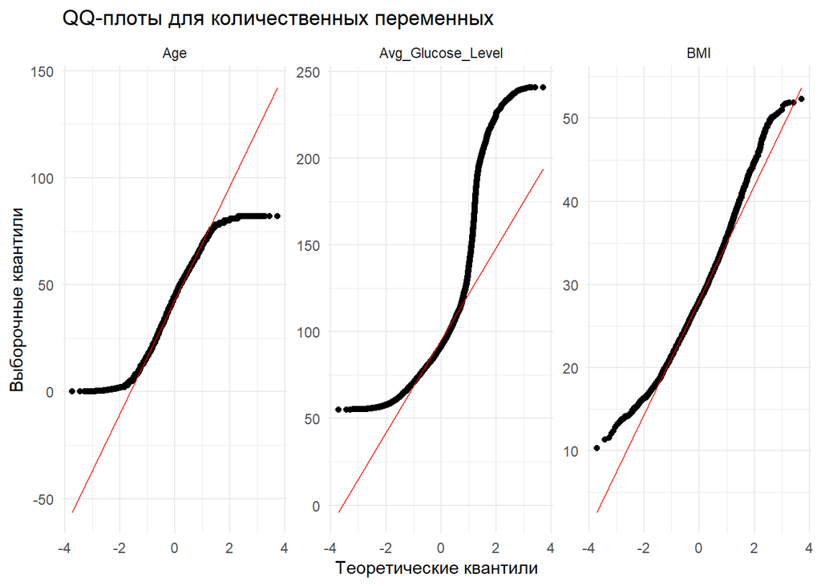

```r
q_vars <- cleaned_data %>%
  select(Age, Avg_Glucose_Level, BMI) %>%
  pivot_longer(cols = everything(), names_to = "Переменная", values_to = "Значение") %>%
  filter(!is.na(Значение))


ggplot(q_vars, aes(sample = Значение)) +
  stat_qq() +
  stat_qq_line(color = "red") +
  facet_wrap(~Переменная, scales = "free_y") +
  labs(x = "Теоретические квантили", y = "Выборочные квантили", title = "QQ-плоты для количественных переменных") +
  theme_minimal()
```

3. Ниже напишите, какие ещё методы проверки на нормальность вы знаете и какие у них есть ограничения.

Тест Колмогорова-Смирнова (K-S тест). Преимущества: Хорош для небольших выборок. Ограничения: при больших объемах данных малейшие отклонения приводят к отклонению нулевой гипотезы, даже если распределение близко к нормальному.

Тест Андерсона-Дарлинга: Преимущества: Более мощный, чем K-S тест, особенно при работе с данными, содержащими выбросы.Ограничения: Требует достаточно больших выборок для корректного применения. Может быть слишком строгим для небольших выборок и малых отклонений.

## Сравнение групп

1. Сравните группы (переменная **stroke**) по каждой переменной (как количественной, так и категориальной). Для каждой переменной выберите нужный критерий и кратко обоснуйте его выбор в комментариях.

Комментарий: Манна-Уитни: Выбран для количественных переменных, так как распределение не является нормальным. Хи-квадрат тест: Применил к категориальным переменным, поскольку в выборке достаточно данных для выполнения теста с ожидаемыми значениями в таблице частот.

```r
quant_results <- cleaned_data %>%
  select(where(is.numeric), Stroke_Status, -Unique_ID) %>%
  pivot_longer(cols = -Stroke_Status, names_to = "Variable", values_to = "Value") %>%
  group_by(Variable) %>%
  summarise(
    p_value = wilcox.test(Value ~ Stroke_Status)$p.value,
    significance = ifelse(p_value < 0.05, "Различие между группами есть", "Различие между группами не доказано")
  )

quant_table <- quant_results %>%
  flextable() %>%
  set_header_labels(
    Variable = "Переменная",
    p_value = "p-значение",
    significance = "Значимость"
  ) %>%
  theme_box() %>%
  autofit() %>%
  align(align = "center", part = "all")

print(quant_table)
```

```
## a flextable object.
## col_keys: `Variable`, `p_value`, `significance`
## header has 1 row(s)
## body has 3 row(s)
## original dataset sample:
##            Variable      p_value                 significance
## 1               Age 1.280740e-68 Различие между группами есть
## 2 Avg_Glucose_Level 1.605544e-07 Различие между группами есть
## 3               BMI 2.523395e-04 Различие между группами есть
```

```r
cat_vars <- cleaned_data %>%
  select(where(is.factor), -Unique_ID, -Stroke_Status) %>% colnames()
cat_results <- map_df(cat_vars, function(var) {
  table_data <- table(cleaned_data[[var]], cleaned_data$Stroke_Status)
  test_result <- chisq.test(table_data)
  tibble(
    Variable = var,
    p_value = test_result$p.value,
    significance = ifelse(test_result$p.value < 0.05, "Различие между группами есть", "Различие между группами не доказано")
  )
})
cat_table <- cat_results %>%
  flextable() %>%
  set_header_labels(
    Variable = "Переменная",
    p_value = "p-значение",
    significance = "Значимость"
  ) %>%
  theme_box() %>%
  autofit() %>%
  align(align = "center", part = "all")

print(cat_table)
```

```
## a flextable object.
## col_keys: `Variable`, `p_value`, `significance`
## header has 1 row(s)
## body has 6 row(s)
## original dataset sample:
##         Variable      p_value                        significance
## 1         Gender 9.468267e-01 Различие между группами не доказано
## 2   Hypertension 3.275440e-17        Различие между группами есть
## 3  Heart_Disease 1.344301e-18        Различие между группами есть
## 4      Work_Type 3.183359e-10        Различие между группами есть
## 5 Residence_Type 2.318313e-01 Различие между группами не доказано
```

# Далее идут **необязательные** дополнительные задания, которые могут принести вам дополнительные баллы в том числе в случае ошибок в предыдущих

## Корреляционный анализ

1. Создайте корреляционную матрицу с визуализацией и поправкой на множественные сравнения. Объясните, когда лучше использовать корреляционные матрицы и в чём минусы и плюсы корреляционных исследований. Корреляционные матрицы – это удобный способ увидеть, как связаны между собой разные показатели: они показывают, какие переменные “двигаются” вместе, и насколько сильна эта связь. Однако корреляция не значит, что одна переменная влияет на другую, и хорошо работает только для простых, линейных связей. Также на результаты могут сильно влиять выбросы – значения, резко выделяющиеся на фоне остальных.

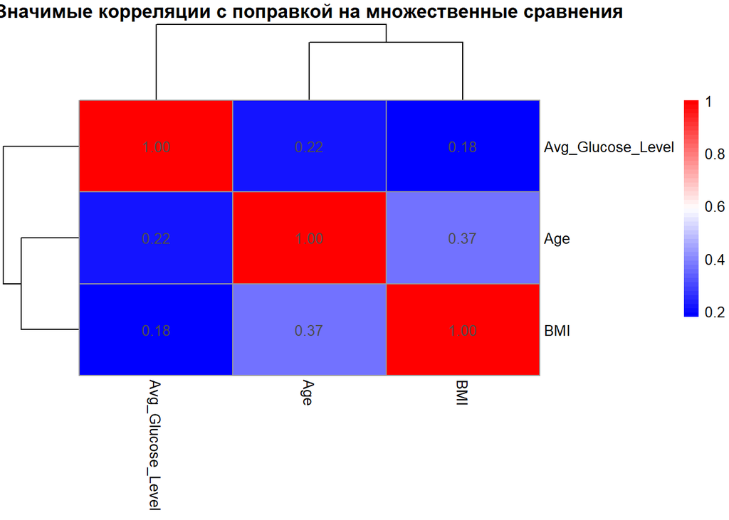

```r
cor_matrix <- cleaned_data %>%
  select(where(is.numeric), -Unique_ID) %>%
  cor(method = "pearson", use = "pairwise.complete.obs")

p_matrix <- cor_pmat(cleaned_data %>% select(where(is.numeric)))

p_adjusted <- p.adjust(p_matrix, method = "BH")

cor_matrix[is.na(cor_matrix)] <- 0

pheatmap(
  cor_matrix,
  display_numbers = TRUE,
  number_format = "%.2f",
  color = colorRampPalette(c("blue", "white", "red"))(50),
  main = "Значимые корреляции с поправкой на множественные сравнения",
  fontsize_number = 10,
  cluster_rows = TRUE,
  cluster_cols = TRUE,
  na_col = "grey"
)
```

## Моделирование

1. Постройте регрессионную модель для переменной **stroke**. Опишите процесс построения